# Property Value Prediction Model for King County, Washington

Christina Mitchell

2024-03-29

```css
pre.foldable {
  background-color: lightgreen;
}
```

# Property Value Prediction in King County, Washington

This predictive model implores structural and location characteristics to determine home prices in King County, Washington. The results of this model highlight key indicators for home price such as bathrooms, square footage, and being in a good school district. The results are further supported by the statistical significance of the model and overall good fit.

# 1) Data

Data for this model includes King County House Data, provided by Marie-Antoinette Predictions (MAP) Inc., parks and school districts data from King County Open Data, and data for school graduation rates from the Washington State Report Card.

```r
csv_url <- "https://raw.githubusercontent.com/cnmitch01/PPA-Midterm/main/data/kc_house_data.csv"

parks_url <- "https://raw.githubusercontent.com/cnmitch01/PPA-Midterm/main/data/park_facilities.csv"

graduation_url <- "https://raw.githubusercontent.com/cnmitch01/PPA-Midterm/main/data/kc_graduation_rates_2014-2015.csv"

districts_url <- "https://raw.githubusercontent.com/cnmitch01/PPA-Midterm/main/data/School_Districts.geojson"

kc_house_data <- read_csv(csv_url)

kc_parks_data <- st_read(parks_url)

kc_graduation_data <- st_read(graduation_url)

kc_districts_data <- st_read(districts_url)
```

## Gathering Outside Data and Making Variables

In addition to variables such as bedrooms and bathrooms, which were provided in the King County House Data set, variables such as parks and graduation rates were considered regarding the impact they might have on home sale price. The code chunk below details the data cleaning and wrangling associated with incorporating these variables into the model. In summary, nearest neighbor calculations were utilized to create variables which highlighted how close each home was to a single park, two parks, three parks, and finally four parks. The difficulty with parks, however, is that the connotation associated with them vary by neighborhood. Conducting a nearest neighbor analysis beyond k = 1 partially accounts for this, as the physical makeup of a neighborhood with one park likely varies from a neighborhood with four.

The suspected varied relationship between parks and home sale price partially influenced the inclusion of the graduation rates variable. To include this variable in the model in a way that made sense required filtering for districts with four-year high school graduation rates above 90%. Once these districts were determined, calculations were conducted to return “1” for homes which fell into these school districts and “0” for homes that did not.

```r
#Making the data spatial
kc_house_sf <- st_as_sf(kc_house_data, coords = c("long", "lat"), crs = "EPSG:4326")

kc_parks_sf <- st_as_sf(kc_parks_data, coords = c("X", "Y"), crs = "EPSG:4326")

#Organizing parks data to incorporate as variable for model
kc_parks_sf <- kc_parks_sf %>%
            filter(SiteType == "Park Site")

#Adding parks nearest neighbor to variables sf
kc_variables_sf <-
  kc_house_sf %>%
    mutate(
      parks_nn1 = nn_function(st_coordinates(kc_house_sf),
                              st_coordinates(kc_parks_sf), k = 1),
      parks_nn2 = nn_function(st_coordinates(kc_house_sf),
                              st_coordinates(kc_parks_sf), k =2),
      parks_nn3 = nn_function(st_coordinates(kc_house_sf),
                              st_coordinates(kc_parks_sf), k =3),
      parks_nn4 = nn_function(st_coordinates(kc_house_sf),
                              st_coordinates(kc_parks_sf), k =4))

#Bringing in schools data

## First - graduation rates by district
kc_graduation_data <- kc_graduation_data %>%
  filter(County == "King" & StudentGroupType == "All"& Cohort == "Four Year") %>% #four-year graduation rate for all students in KC
  dplyr::select(DistrictCode, DistrictName, SchoolCode, SchoolName, GraduationRate) %>%
  mutate(GraduationRate = as.numeric(GraduationRate)) %>%
  drop_na(GraduationRate) %>%
  filter(GraduationRate > .90) %>%  #filtering for districts with graduation rates greater than 90%
  group_by(DistrictName, DistrictCode) %>%
  summarise(mean(GraduationRate)) %>%
  rename(NAME = DistrictName) %>%
  mutate(NAME = gsub(" School District", "", NAME)) %>%
  mutate(NAME = gsub(" No. 1", "", NAME))



#Joining graduation rates to districts for spatial info

kc_districts_data <- as.data.frame(kc_districts_data)

kc_schools_data <- inner_join(kc_districts_data, kc_graduation_data)

kc_schools_sf <- st_as_sf(kc_schools_data)

#Homes that fall into districts with average graduation rates of over 90%
kc_house_sf <- st_transform(kc_house_sf, st_crs(kc_schools_sf))

kc_variables_sf <- kc_variables_sf %>%
  mutate(
    in_district = as.integer(ifelse(st_within(kc_house_sf, kc_schools_sf), 1, 0))
  ) %>%
  replace_na(replace = list(in_district = 0))

#Creating dataframe with all variables
kc_variables <- kc_variables_sf %>%
  mutate(Age = 2015 - yr_built) %>%
  st_drop_geometry() %>%
  select_if(is.numeric) %>%
  na.omit()
```

## Summary Statistics - Understanding the Data

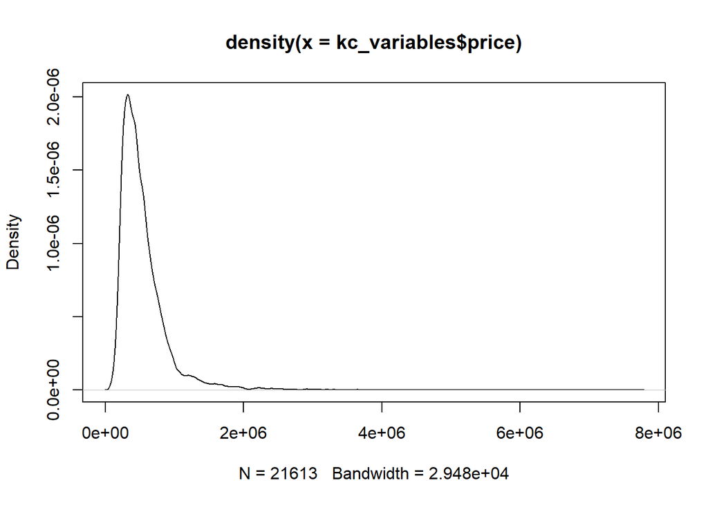

```r
#Density plot of price variable
plot(density(kc_variables$price))
```

```r
#Converting kc_variables tibble into proper data frame for summary statistics
kc_variables <- as.data.frame(kc_variables)

#Summary Statistics Tables

##Internal and Physical Characteristics
physical <- kc_variables[, c("price", "bedrooms", "bathrooms", "sqft_living", "sqft_lot", "condition", "grade", "sqft_above", "sqft_basement", "yr_built", "yr_renovated", "Age")]

variable_labels <- c("Home Sale Price", "Number of Bedrooms", "Number of Bathrooms", "Square Footage of House", "Square Footage of Lot", "House Condition", "House Grade", "Square Footage Above House", "Square Footage of Basement", "Year House Built", "Year House Renovated", "Age of House")


table_one <- stargazer(physical, type = "html", style = "default", title = "Physical Characteristics",
                             covariate.labels = variable_labels, column.sep.width = "200px")
```

**Physical Characteristics**

| Statistic | N | Mean | St. Dev. | Min | Max |
| --- | --- | --- | --- | --- | --- |
| Home Sale Price | 21,613 | 540,088.100 | 367,127.200 | 75,000 | 7,700,000 |
| Number of Bedrooms | 21,613 | 3.371 | 0.930 | 0 | 33 |
| Number of Bathrooms | 21,613 | 2.115 | 0.770 | 0.000 | 8.000 |
| Square Footage of House | 21,613 | 2,079.900 | 918.441 | 290 | 13,540 |
| Square Footage of Lot | 21,613 | 15,106.970 | 41,420.510 | 520 | 1,651,359 |
| House Condition | 21,613 | 3.409 | 0.651 | 1 | 5 |
| House Grade | 21,613 | 7.657 | 1.175 | 1 | 13 |
| Square Footage Above House | 21,613 | 1,788.391 | 828.091 | 290 | 9,410 |
| Square Footage of Basement | 21,613 | 291.509 | 442.575 | 0 | 4,820 |
| Year House Built | 21,613 | 1,971.005 | 29.373 | 1,900 | 2,015 |
| Year House Renovated | 21,613 | 84.402 | 401.679 | 0 | 2,015 |
| Age of House | 21,613 | 43.995 | 29.373 | 0 | 115 |

```r
##Amenities
amenities <- kc_variables[, c("parks_nn1", "parks_nn2", "parks_nn3", "parks_nn4", "in_district", "waterfront", "view")]

variable_labels2 <- c("Home Distance to One Park", "Home Distance to Two Parks", "Home Distance to Three Parks", "Home Distance to Four Parks", "In Good School District", "Waterfront", "View")

table_two <- stargazer(amenities, type = "html", style = "default", title = "Amenities", covariate.labels = variable_labels2, column.sep.width = "200px")
```

**Amenities**

| Statistic | N | Mean | St. Dev. | Min | Max |
| --- | --- | --- | --- | --- | --- |
| Home Distance to One Park | 21,613 | 0.017 | 0.014 | 0.0002 | 0.392 |
| Home Distance to Two Parks | 21,613 | 0.019 | 0.015 | 0.0002 | 0.420 |
| Home Distance to Three Parks | 21,613 | 0.020 | 0.015 | 0.0003 | 0.436 |
| Home Distance to Four Parks | 21,613 | 0.021 | 0.016 | 0.0004 | 0.444 |
| In Good School District | 21,613 | 0.774 | 0.418 | 0 | 1 |
| Waterfront | 21,613 | 0.008 | 0.087 | 0 | 1 |
| View | 21,613 | 0.234 | 0.766 | 0 | 4 |

# 2) Mapping the Data

The maps included in this section are of the key variables in this predictive model. These include the dependent variable of home price, and the independent variables of parks, graduation rates, and home age.

## Sale Price (Dependent Variable)

The sale price map below highlights the spatial distribution of home prices in King County. The northern part of the county appears to have higher home values than its southern counterpart.

```r
# base map
kingtracts <-
  get_acs(geography = "tract", variables = c("B25026_001E","B25058_001E"),
          year=2015, state=53, county="King", geometry=T, output="wide") %>%
  st_transform('EPSG:4326') %>%
  rename(TotalPop = B25026_001E,
         MedRent = B25058_001E)
```

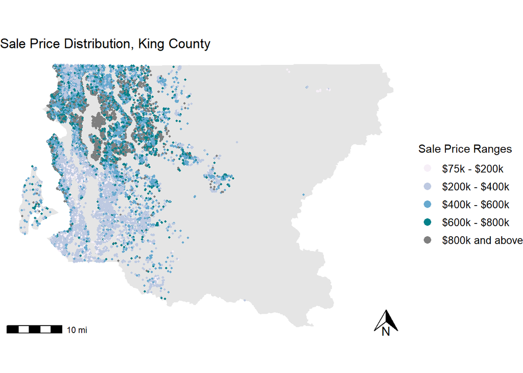

```r
# mapping sale price
colors <- brewer.pal(4, "PuBuGn")
breaks <- c(75000, 200000, 400000, 600000, 800000)  # Example breaks
labels <- c(paste0("$", formatC(breaks[1], format = "d", big.mark = ",")),
            paste0("$", formatC(breaks[2], format = "d", big.mark = ",")),
            paste0("$", formatC(breaks[3], format = "d", big.mark = ",")),
            paste0("$", formatC(breaks[4], format = "d", big.mark = ",")),
            paste0("$", formatC(breaks[5], format = "d", big.mark = ",")))

# Create labels with explicit range in k format
range_labels <- c(
  paste0("$", formatC(breaks[1] / 1000, digits = 0, format = "d", big.mark = ","), "k - ",
         "$", formatC(breaks[2] / 1000, digits = 0, format = "d", big.mark = ","), "k"),
  paste0("$", formatC(breaks[2] / 1000, digits = 0, format = "d", big.mark = ","), "k - ",
         "$", formatC(breaks[3] / 1000, digits = 0, format = "d", big.mark = ","), "k"),
  paste0("$", formatC(breaks[3] / 1000, digits = 0, format = "d", big.mark = ","), "k - ",
         "$", formatC(breaks[4] / 1000, digits = 0, format = "d", big.mark = ","), "k"),
  paste0("$", formatC(breaks[4] / 1000, digits = 0, format = "d", big.mark = ","), "k - ",
         "$", formatC(breaks[5] / 1000, digits = 0, format = "d", big.mark = ","), "k"),
  paste0("$", formatC(breaks[5] / 1000, digits = 0, format = "d", big.mark = ","), "k and above")
)

# Plot the map with price quintiles differentiated by color and labeled legend
ggplot() +
  geom_sf(data = kingtracts, color = NA) +
  geom_sf(data = kc_variables_sf, aes(colour = cut(price, breaks = breaks, include.lowest = TRUE)),
          show.legend = "point", size = 0.75) +
  scale_colour_manual(values = colors, labels = range_labels, name = "Sale Price Ranges") +
  labs(title = "Sale Price Distribution, King County") +
  annotation_scale(location="bl", unit_category="imperial") +
  annotation_north_arrow(location = "br", which_north = "true",
                          height = unit(0.8, "cm"),
                          width = unit(0.8, "cm"),
                          pad_x = unit(0.50, "cm"),
                          pad_y = unit(0.25, "cm")) +
  theme_void() +
  theme(legend.text = element_text(size = 10)) +
  guides(colour = guide_legend(override.aes = list(size = 3)))
```

## Parks (Independent Variable #1)

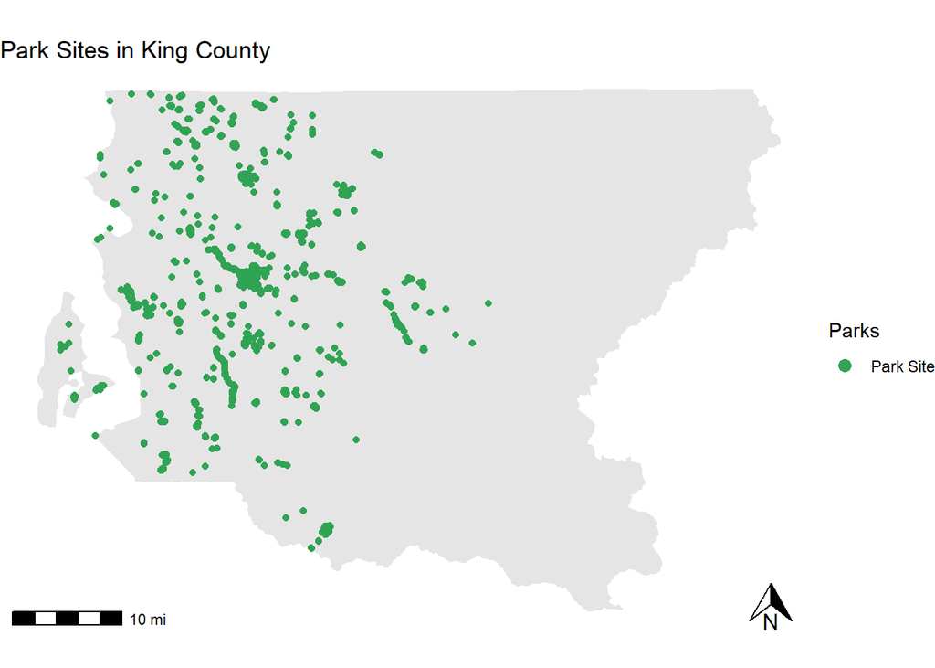

```r
ggplot() +
  geom_sf(data = kingtracts, color = NA) +
  geom_sf(data = kc_parks_sf, aes(colour = SiteType)) +
  scale_colour_manual(values = "#31a354", name = "Parks") +
  labs(title = "Park Sites in King County") +
   annotation_scale(location="bl", unit_category="imperial") +
  annotation_north_arrow(location = "br", which_north = "true",
                          height = unit(0.8, "cm"),
                          width = unit(0.8, "cm"),
                          pad_x = unit(0.50, "cm"),
                          pad_y = unit(0.25, "cm")) +
  theme(legend.text = element_text(size = 10)) +
  guides(colour = guide_legend(override.aes = list(size = 3))) +
  theme_void()
```

## Graduation Rates (Independent Variable #2)

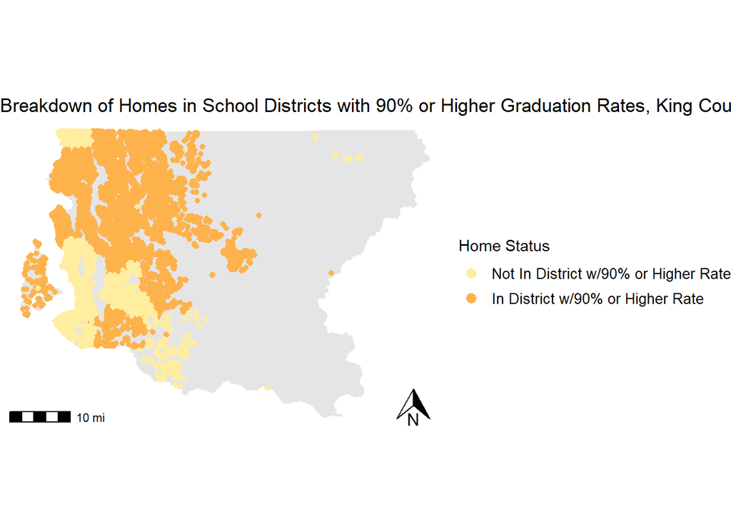

```r
colors <- brewer.pal(2, "YlOrRd")
labels <- c("Not In District w/90% or Higher Rate", "In District w/90% or Higher Rate")


ggplot() +
  geom_sf(data = kingtracts, color = NA) +
  geom_sf(data = kc_variables_sf, aes(color = factor(in_district))) +
  scale_colour_manual(values = colors, labels = labels, name = "Home Status") +
  labs(title = "Breakdown of Homes in School Districts with 90% or Higher Graduation Rates, King County") +
   annotation_scale(location="bl", unit_category="imperial") +
  annotation_north_arrow(location = "br", which_north = "true",
                          height = unit(0.8, "cm"),
                          width = unit(0.8, "cm"),
                          pad_x = unit(0.50, "cm"),
                          pad_y = unit(0.25, "cm")) +
  theme_void() +
  theme(legend.text = element_text(size = 10)) +
  guides(colour = guide_legend(override.aes = list(size = 3)))
```

## Year Built (Independent Variable #3)

This map highlights the spatial distribution of homes in King County based on the year they were built. Based on the output of this map, it is evident that most homes in the county were built after 1950. This is important in understanding the relationship between home age and price. In cities where many homes are deemed “historic” (pre 1950s or even 1900) the relationship with sale price might be linear or even exponential, whereby demand is for those extremely historic homes or new ones. Cities such as Seattle and King County at large however appear to have a smaller stock of historic homes which likely affects the correlation between home age and sale price.

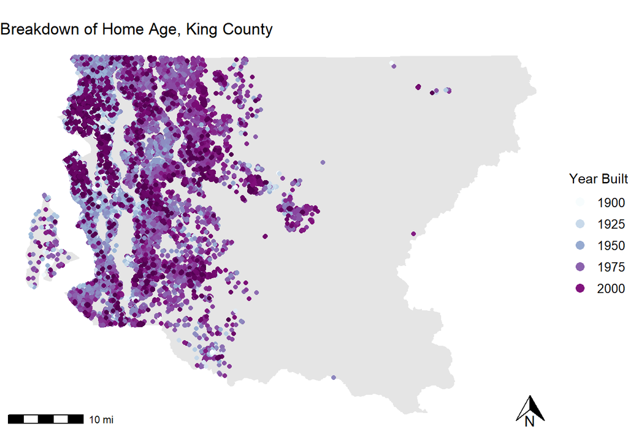

```r
colors <- brewer.pal(9, "BuPu")

ggplot() +
  geom_sf(data = kingtracts, color = NA) +
  geom_sf(data = kc_variables_sf, aes(color = yr_built)) +
  scale_colour_gradientn(colors = colors, name = "Year Built") +
  labs(title = "Breakdown of Home Age, King County") +
  annotation_scale(location="bl", unit_category="imperial") +
  annotation_north_arrow(location = "br", which_north = "true",
                         height = unit(0.8, "cm"),
                         width = unit(0.8, "cm"),
                         pad_x = unit(0.50, "cm"),
                         pad_y = unit(0.25, "cm")) +
  theme_void() +
  theme(legend.text = element_text(size = 10)) +
  guides(colour = guide_legend(override.aes = list(size = 3)))
```

# 3) Correlation in the Data

## Correlation Matrix

The matrix below highlights the correlation between variables in the data set for the model and indicates which variables might cause multicollinearity. Understanding which variables might cause an issue of collinearity (such as bedrooms and bathrooms) assisted in development of this model and choice in variables.

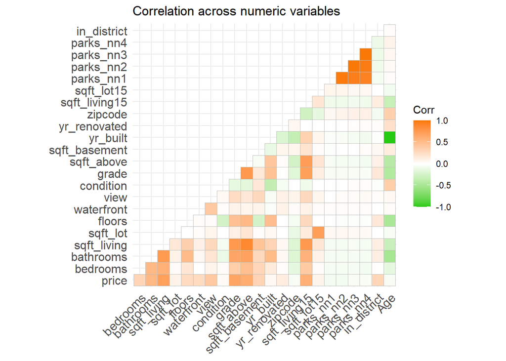

```r
correlation_matrix <- cor(kc_variables)


ggcorrplot(
  correlation_matrix,  # Correlation matrix
  p.mat = cor_pmat(kc_variables),  # p-values for significance
  colors = c("#25CB10", "white", "#FA7800"),  # Custom color palette
  type = "lower",  # Lower triangle of the correlation matrix
  insig = "blank"  # Hide insignificant correlations
) +
labs(title = "Correlation across numeric variables")
```

## Home Price Correlation Scatter Plots

The scatter plots below highlight the relationship between price and the variables of bathrooms, in_district, parks_nn4, and sqft_living. Only the relationship between price and sqft_living appears to be linear.

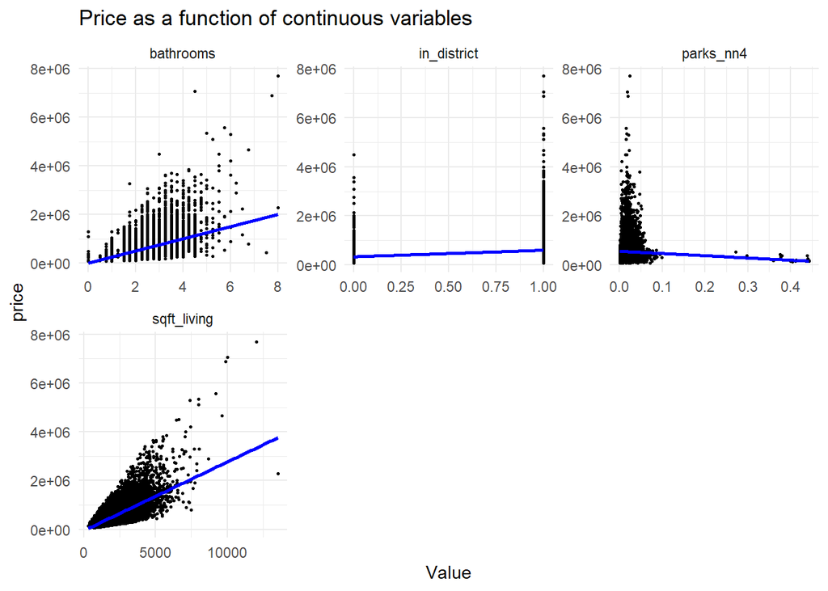

```r
kc_selection <- kc_variables %>%
  dplyr::select(price, bathrooms, sqft_living, in_district, parks_nn4)

kc_long <- gather(kc_selection, Variable, Value, -price)

ggplot(kc_long, aes(Value, price)) +   # Set up the plot
  geom_point(size = .5) +                       # Add points for each data point
  geom_smooth(method = "lm", se = FALSE, colour = "Blue") +  # Add linear regression lines
  facet_wrap(~Variable, ncol = 3, scales = "free") +  # Create separate plots for each variable
  labs(title = "Price as a function of continuous variables") +  # Set plot title
  theme_minimal()
```

# 4) Building Out the Model

## Testing and Training

To build out the model, the data set is split into testing and training.

```r
#80/20 split for testing and training
set.seed(1)
row.number <- sample(1:nrow(kc_variables), 0.8*nrow(kc_variables))
train = kc_variables[row.number,]
test = kc_variables[-row.number,]
dim(train)
dim(test)
```

## Practice Models

Two practice models were conducted to identify which variables were statistically significant and which ones were not. The first model includes all of the dependent variables in the training data set and the second includes all variables but those which were identified as statistically insignificant from the first model. A log transformation of the price variable was also done to account for the skewed distribution of home price in King County, which was identified in the density plot in section 1.

The residuals plots of model 2 indicate room for improvement as the scatter of residuals increase from left to right in the Residuals vs. Fitted plot and the Q-Q residuals plot highlights a slightly imperfect line.

```r
#just doing some practice models
model1 = lm(log(price)~., data=train)
summary(model1)
```

```
##
## Call:
## lm(formula = log(price) ~ ., data = train)
##
## Residuals:
##      Min       1Q   Median       3Q      Max
## -1.49069 -0.16101  0.01175  0.16817  1.11802
##
## Coefficients: (2 not defined because of singularities)
##                 Estimate Std. Error t value Pr(>|t|)
## (Intercept)   -4.650e+01  4.404e+00 -10.558  < 2e-16 ***
## bedrooms      -4.626e-03  2.803e-03  -1.650 0.098907 .
## bathrooms      5.741e-02  4.838e-03  11.867  < 2e-16 ***
## sqft_living    1.557e-04  6.506e-06  23.926  < 2e-16 ***
## sqft_lot       3.387e-07  7.824e-08   4.329 1.50e-05 ***
## floors         4.150e-02  5.430e-03   7.642 2.26e-14 ***
## waterfront     4.279e-01  2.598e-02  16.468  < 2e-16 ***
## view           3.810e-02  3.168e-03  12.024  < 2e-16 ***
## condition      5.610e-02  3.467e-03  16.180  < 2e-16 ***
## grade          1.732e-01  3.179e-03  54.502  < 2e-16 ***
## sqft_above    -2.176e-05  6.475e-06  -3.360 0.000782 ***
## sqft_basement         NA         NA      NA       NA
## yr_built      -3.511e-03  1.060e-04 -33.112  < 2e-16 ***
## yr_renovated   2.659e-05  5.464e-06   4.866 1.15e-06 ***
## zipcode        6.522e-04  4.419e-05  14.760  < 2e-16 ***
## sqft_living15  1.065e-04  5.090e-06  20.927  < 2e-16 ***
## sqft_lot15    -5.241e-07  1.111e-07  -4.717 2.41e-06 ***
## parks_nn1     -2.202e+00  8.663e-01  -2.541 0.011051 *
## parks_nn2     -1.168e+00  1.979e+00  -0.590 0.554985
## parks_nn3     -1.547e+01  2.689e+00  -5.752 8.98e-09 ***
## parks_nn4      1.781e+01  1.524e+00  11.687  < 2e-16 ***
## in_district    3.817e-01  5.222e-03  73.084  < 2e-16 ***
## Age                   NA         NA      NA       NA
## ---
## Signif. codes:  0 '***' 0.001 '**' 0.01 '*' 0.05 '.' 0.1 ' ' 1
##
## Residual standard error: 0.2678 on 17269 degrees of freedom
## Multiple R-squared:  0.7412, Adjusted R-squared:  0.7409
## F-statistic:  2473 on 20 and 17269 DF,  p-value: < 2.2e-16
```

```r
model2 = update(model1, ~.-bedrooms-sft_basement-parks_nn1-parks_nn2)
summary(model2)
```

```
##
## Call:
## lm(formula = log(price) ~ bathrooms + sqft_living + sqft_lot +
##     floors + waterfront + view + condition + grade + sqft_above +
##     sqft_basement + yr_built + yr_renovated + zipcode + sqft_living15 +
##     sqft_lot15 + parks_nn3 + parks_nn4 + in_district + Age, data = train)
##
## Residuals:
##      Min       1Q   Median       3Q      Max
## -1.48078 -0.16126  0.01034  0.16812  1.10579
##
## Coefficients: (2 not defined because of singularities)
##                 Estimate Std. Error t value Pr(>|t|)
## (Intercept)   -4.684e+01  4.396e+00 -10.654  < 2e-16 ***
## bathrooms      5.607e-02  4.744e-03  11.819  < 2e-16 ***
## sqft_living    1.528e-04  6.281e-06  24.333  < 2e-16 ***
## sqft_lot       3.441e-07  7.825e-08   4.397 1.10e-05 ***
## floors         4.109e-02  5.430e-03   7.568 3.98e-14 ***
## waterfront     4.311e-01  2.597e-02  16.601  < 2e-16 ***
## view           3.834e-02  3.161e-03  12.130  < 2e-16 ***
## condition      5.623e-02  3.464e-03  16.232  < 2e-16 ***
## grade          1.744e-01  3.154e-03  55.277  < 2e-16 ***
## sqft_above    -2.215e-05  6.477e-06  -3.420 0.000627 ***
## sqft_basement         NA         NA      NA       NA
## yr_built      -3.498e-03  1.057e-04 -33.086  < 2e-16 ***
## yr_renovated   2.711e-05  5.464e-06   4.961 7.07e-07 ***
## zipcode        6.552e-04  4.412e-05  14.851  < 2e-16 ***
## sqft_living15  1.076e-04  5.087e-06  21.148  < 2e-16 ***
## sqft_lot15    -5.175e-07  1.111e-07  -4.658 3.22e-06 ***
## parks_nn3     -2.219e+01  1.183e+00 -18.759  < 2e-16 ***
## parks_nn4      2.140e+01  1.140e+00  18.764  < 2e-16 ***
## in_district    3.784e-01  5.135e-03  73.694  < 2e-16 ***
## Age                   NA         NA      NA       NA
## ---
## Signif. codes:  0 '***' 0.001 '**' 0.01 '*' 0.05 '.' 0.1 ' ' 1
##
## Residual standard error: 0.2679 on 17272 degrees of freedom
## Multiple R-squared:  0.7409, Adjusted R-squared:  0.7406
## F-statistic:  2905 on 17 and 17272 DF,  p-value: < 2.2e-16
```

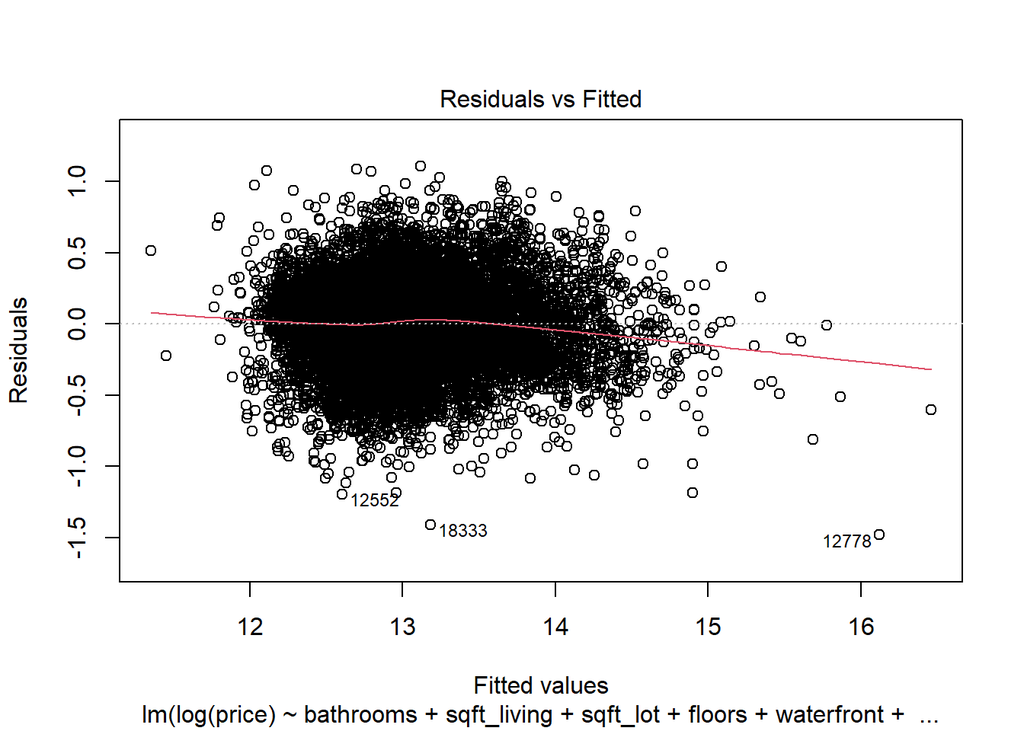

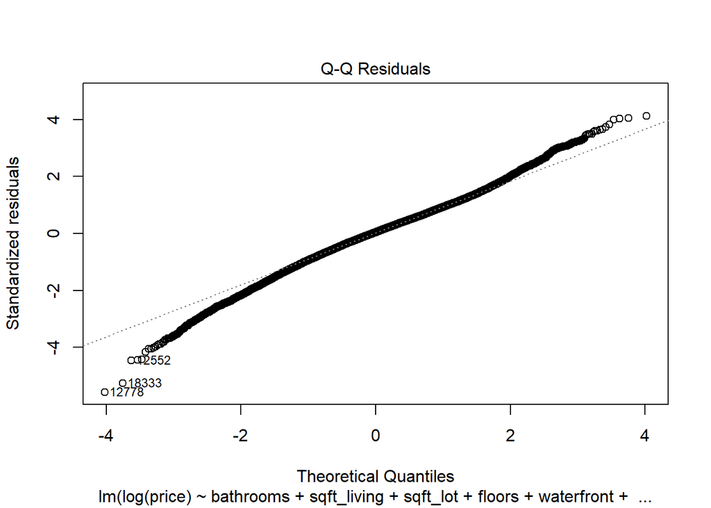

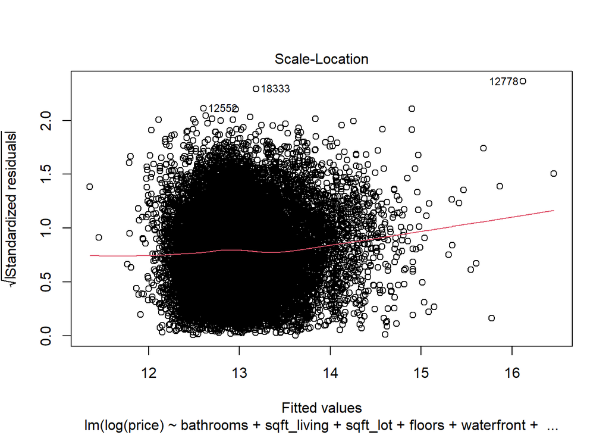

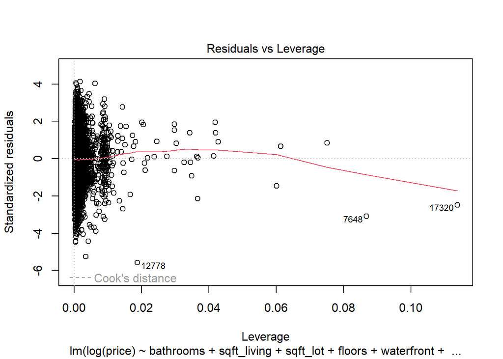

```r
#plotting residuals
plot(model2)
```

## Checking for Exponential Relationships

The model below was created to check for exponential relationships in the data and identify those exponential variables with statistical significance.

```r
#checking for exponential relationships
model3 = lm(log(price)~ bathrooms + sqft_living + sqft_lot +
    floors + waterfront + view + condition + grade + sqft_above +
    sqft_basement + yr_built + yr_renovated + zipcode + sqft_living15 +
    sqft_lot15 + parks_nn3 + parks_nn4 + in_district + Age + I(bathrooms^2) + I(sqft_living^2) + I(sqft_lot^2) + I(floors^2) + I(waterfront^2) + I(view^2) + I(condition^2) + I(grade^2) + I(sqft_above^2) + I(sqft_basement^2) + I(yr_built^2) + I(yr_renovated^2) + I(zipcode^2) + I(sqft_living15^2) + I(sqft_lot15^2) + I(parks_nn3^2) +I(parks_nn4^2) + I(in_district^2) + I(Age^2), data = train)

summary(model3)
```

```
##
## Call:
## lm(formula = log(price) ~ bathrooms + sqft_living + sqft_lot +
##     floors + waterfront + view + condition + grade + sqft_above +
##     sqft_basement + yr_built + yr_renovated + zipcode + sqft_living15 +
##     sqft_lot15 + parks_nn3 + parks_nn4 + in_district + Age +
##     I(bathrooms^2) + I(sqft_living^2) + I(sqft_lot^2) + I(floors^2) +
##     I(waterfront^2) + I(view^2) + I(condition^2) + I(grade^2) +
##     I(sqft_above^2) + I(sqft_basement^2) + I(yr_built^2) + I(yr_renovated^2) +
##     I(zipcode^2) + I(sqft_living15^2) + I(sqft_lot15^2) + I(parks_nn3^2) +
##     I(parks_nn4^2) + I(in_district^2) + I(Age^2), data = train)
##
## Residuals:
##      Min       1Q   Median       3Q      Max
## -1.37000 -0.15809  0.01034  0.16411  1.56292
##
## Coefficients: (5 not defined because of singularities)
##                      Estimate Std. Error t value Pr(>|t|)
## (Intercept)         1.776e+02  7.499e+03   0.024 0.981105
## bathrooms           2.905e-02  1.376e-02   2.111 0.034759 *
## sqft_living         2.378e-04  1.310e-05  18.153  < 2e-16 ***
## sqft_lot            6.815e-07  1.492e-07   4.567 4.99e-06 ***
## floors             -2.077e-01  2.539e-02  -8.178 3.08e-16 ***
## waterfront          4.633e-01  2.796e-02  16.568  < 2e-16 ***
## view                3.443e-02  9.879e-03   3.485 0.000493 ***
## condition           1.123e-01  2.963e-02   3.791 0.000151 ***
## grade               2.485e-01  1.889e-02  13.158  < 2e-16 ***
## sqft_above         -2.990e-05  1.622e-05  -1.843 0.065316 .
## sqft_basement              NA         NA      NA       NA
## yr_built           -7.433e-02  1.087e-02  -6.835 8.45e-12 ***
## yr_renovated       -3.894e-03  6.461e-04  -6.027 1.71e-09 ***
## zipcode            -2.432e-03  1.529e-01  -0.016 0.987306
## sqft_living15       2.641e-04  1.653e-05  15.978  < 2e-16 ***
## sqft_lot15         -1.026e-06  1.946e-07  -5.272 1.37e-07 ***
## parks_nn3          -4.912e+01  2.266e+00 -21.676  < 2e-16 ***
## parks_nn4           4.882e+01  2.276e+00  21.446  < 2e-16 ***
## in_district         3.610e-01  5.483e-03  65.830  < 2e-16 ***
## Age                        NA         NA      NA       NA
## I(bathrooms^2)      2.500e-03  2.707e-03   0.923 0.355815
## I(sqft_living^2)    4.078e-09  2.773e-09   1.471 0.141415
```

[output cut: 8 more lines]

```
## I(yr_built^2)       1.806e-05  2.775e-06   6.508 7.84e-11 ***
## I(yr_renovated^2)   1.964e-06  3.237e-07   6.066 1.34e-09 ***
## I(zipcode^2)        1.533e-08  7.793e-07   0.020 0.984310
## I(sqft_living15^2) -3.290e-08  3.357e-09  -9.802  < 2e-16 ***
## I(sqft_lot15^2)     1.221e-12  3.898e-13   3.134 0.001728 **
## I(parks_nn3^2)      5.200e+02  3.592e+01  14.479  < 2e-16 ***
## I(parks_nn4^2)     -5.011e+02  3.471e+01 -14.438  < 2e-16 ***
## I(in_district^2)           NA         NA      NA       NA
## I(Age^2)                   NA         NA      NA       NA
## ---
## Signif. codes:  0 '***' 0.001 '**' 0.01 '*' 0.05 '.' 0.1 ' ' 1
##
## Residual standard error: 0.2624 on 17256 degrees of freedom
## Multiple R-squared:  0.7517, Adjusted R-squared:  0.7512
## F-statistic:  1583 on 33 and 17256 DF,  p-value: < 2.2e-16
```

## Creating the Final Model

The adjusted R-square for this model sits at .7452, meaning 75% of the variance in the logarithm of prices is explained by the model. All of the variables included in the model are extremely statistically significant with p-values less than .001. These indicators point to this model being a good fit for the data. To further support this claim, a k-fold cross-validation test was run on the training dataset and the outputs of a low RMSE and an R-squared of approximately .74, also point to the good fit of the model.

```r
#remove insignificant variables & variables I don't find interesting
kc_model = update(model3, ~.-sqft_above-sqft_basement-zipcode-Age-I(bathrooms^2)-I(sqft_living^2)-I(sqft_lot^2)-I(waterfront^2)-I(view^2)-I(condition^2)-I(zipcode^2)-I(in_district^2)-I(Age^2)-I(sqft_lot15^2)-sqft_lot15-sqft_living15-sqft_lot)

summary(kc_model)
```

```
##
## Call:
## lm(formula = log(price) ~ bathrooms + sqft_living + floors +
##     waterfront + view + condition + grade + yr_built + yr_renovated +
##     parks_nn3 + parks_nn4 + in_district + I(floors^2) + I(grade^2) +
##     I(sqft_above^2) + I(sqft_basement^2) + I(yr_built^2) + I(yr_renovated^2) +
##     I(sqft_living15^2) + I(parks_nn3^2) + I(parks_nn4^2), data = train)
##
## Residuals:
##      Min       1Q   Median       3Q      Max
## -1.40136 -0.16058  0.00879  0.16767  1.80689
##
## Coefficients:
##                      Estimate Std. Error t value Pr(>|t|)
## (Intercept)         8.915e+01  1.055e+01   8.451  < 2e-16 ***
## bathrooms           4.411e-02  4.759e-03   9.269  < 2e-16 ***
## sqft_living         2.623e-04  8.603e-06  30.487  < 2e-16 ***
## floors             -2.070e-01  2.487e-02  -8.324  < 2e-16 ***
## waterfront          4.676e-01  2.582e-02  18.111  < 2e-16 ***
## view                4.627e-02  3.139e-03  14.740  < 2e-16 ***
## condition           4.800e-02  3.462e-03  13.865  < 2e-16 ***
## grade               3.184e-01  1.782e-02  17.872  < 2e-16 ***
## yr_built           -7.660e-02  1.077e-02  -7.111 1.19e-12 ***
## yr_renovated       -3.770e-03  6.534e-04  -5.769 8.11e-09 ***
## parks_nn3          -5.376e+01  2.262e+00 -23.764  < 2e-16 ***
## parks_nn4           5.371e+01  2.267e+00  23.693  < 2e-16 ***
## in_district         3.510e-01  5.209e-03  67.385  < 2e-16 ***
## I(floors^2)         6.519e-02  7.015e-03   9.294  < 2e-16 ***
## I(grade^2)         -9.030e-03  1.108e-03  -8.147 3.98e-16 ***
## I(sqft_above^2)    -1.780e-08  1.460e-09 -12.192  < 2e-16 ***
## I(sqft_basement^2) -7.354e-08  5.688e-09 -12.928  < 2e-16 ***
## I(yr_built^2)       1.853e-05  2.749e-06   6.740 1.63e-11 ***
## I(yr_renovated^2)   1.898e-06  3.274e-07   5.796 6.90e-09 ***
## I(sqft_living15^2)  1.585e-08  1.028e-09  15.420  < 2e-16 ***
## I(parks_nn3^2)      5.823e+02  3.584e+01  16.245  < 2e-16 ***
## I(parks_nn4^2)     -5.623e+02  3.462e+01 -16.241  < 2e-16 ***
## ---
## Signif. codes:  0 '***' 0.001 '**' 0.01 '*' 0.05 '.' 0.1 ' ' 1
##
## Residual standard error: 0.2656 on 17268 degrees of freedom
## Multiple R-squared:  0.7455, Adjusted R-squared:  0.7452
## F-statistic:  2408 on 21 and 17268 DF,  p-value: < 2.2e-16
```

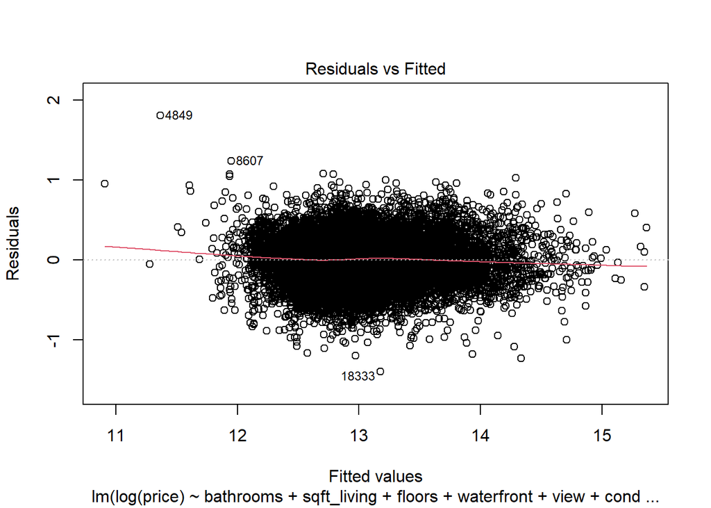

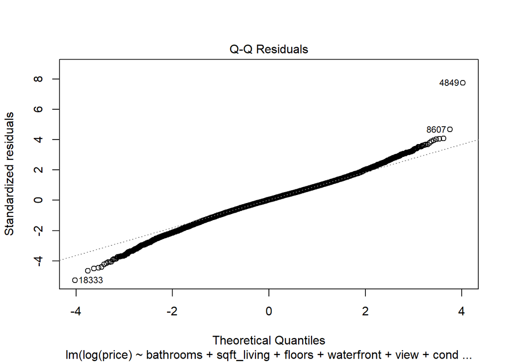

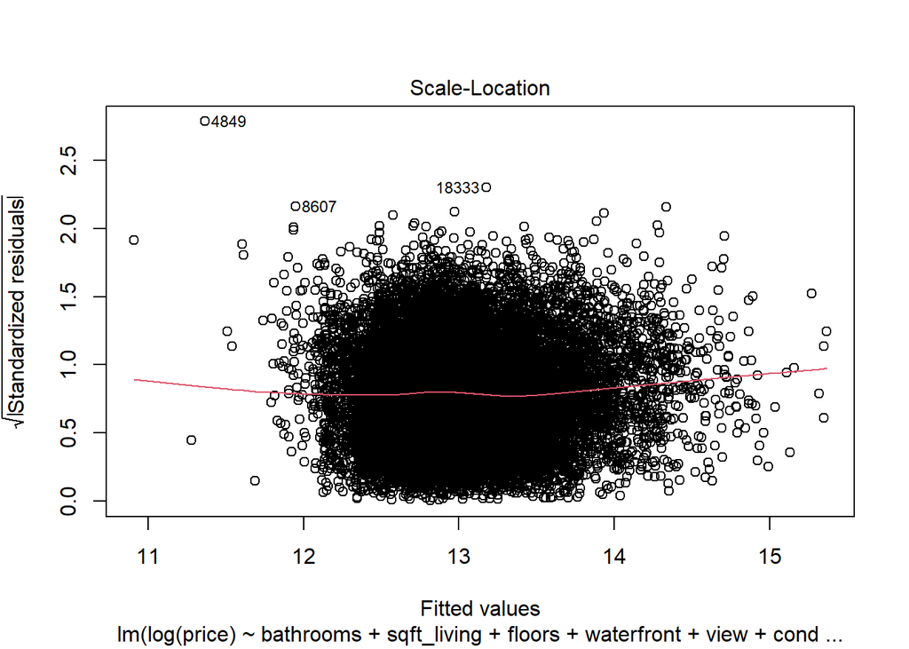

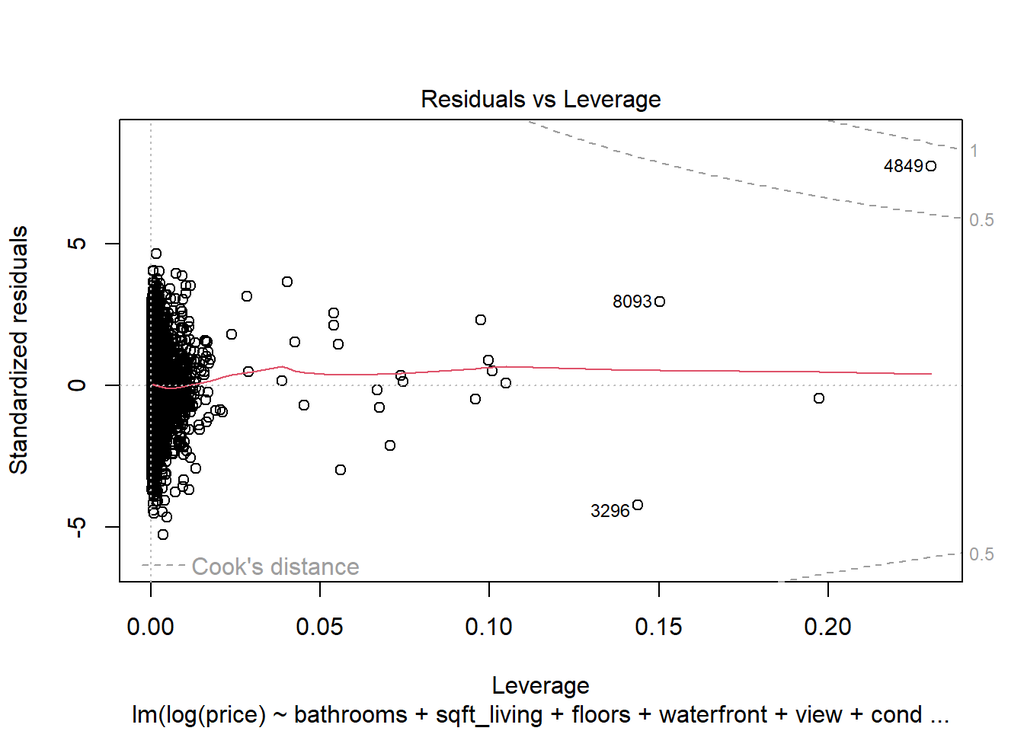

```r
plot(kc_model)
```

```r
#cross-validation
control <- trainControl(method = "cv",
                        number = 10,
                        verboseIter = TRUE,
                        returnData = FALSE,
                        savePredictions = TRUE,
                        classProbs = FALSE,
                        summaryFunction = defaultSummary)

# Train the linear regression model using k-fold cross-validation
kc_cv <- train(log(price) ~ bathrooms + sqft_living + sqft_lot +
      floors + waterfront + view + condition + grade + yr_built + yr_renovated +
      parks_nn3 + parks_nn4 + in_district + I(floors^2) + I(grade^2) +
      I(sqft_above^2) + I(sqft_basement^2) + I(yr_built^2) + I(yr_renovated^2) +
      I(sqft_living15^2)  + I(parks_nn3^2) + I(parks_nn4^2),
      data = train,
      method = "lm",
      trControl = control)
# View the cross-validation results
print(kc_cv)
```

```
## Linear Regression
##
## No pre-processing
## Resampling: Cross-Validated (10 fold)
## Summary of sample sizes: 15561, 15561, 15560, 15562, 15561, 15561, ...
## Resampling results:
##
##   RMSE       Rsquared   MAE
##   0.2661717  0.7439633  0.2052987
##
## Tuning parameter 'intercept' was held constant at a value of TRUE
```

## Evaluating the Final Model with the Test Data Set

The code chunk below evaluates the final model created using the test data set. The result of this evaluation returns an RMSE of ~$200k and an R-squared of ~0.745. The scatter plot associated with this evaluation also showcases the predicted prices as a function of the observed prices. As the prices get higher, the difference between the actual price and the predicted price grow larger, however, lower predicted prices are much more in line with the actual observed price.

```r
#using test dataset to evaluate model - make a prediction based on model 4
pred1 <- predict(kc_model, newdata = test)
rmse <- sqrt(sum((exp(pred1) - test$price)^2)/length(test$price))
c(RMSE = rmse, R2=summary(kc_model)$r.squared)
```

```
##         RMSE           R2
## 1.970442e+05 7.454823e-01
```

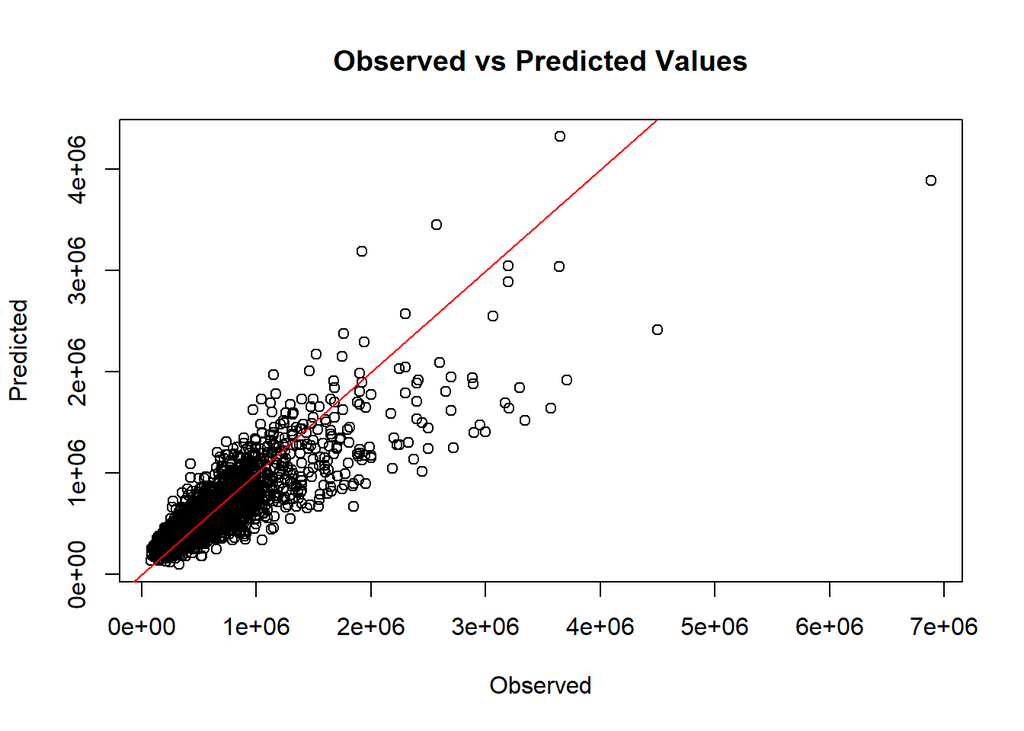

```r
#plot - compares test (actual) prices to predicted prices
par(mfrow=c(1,1))
plot(test$price, exp(pred1),
     xlab = "Observed", ylab = "Predicted",
     main = "Observed vs Predicted Values")
abline(0, 1, col = "red")
```

# 5) Conclusion

## Key Findings

Overall, the model fit appears to be positive. The high R-squared of 0.7455 indicates that approximately 75% of the variance in the log transformation of the home price variable is explained by the predictor variables. In addition, the coefficients in the model have extremely low p-values, indicating that they are statistically significant predictors of price. The log transformation done on the home price variable was key to accounting for the skewed distribution of the data.

## Areas for Improvement

Though the log transformation done on the home price variable was key to accounting for the skewed distribution of data, this made interpreting the coefficients in the model difficult. Perhaps a future iteration of this project would involve cutting out home prices over one million or placing them in a separate data set to have more evenly distributed home prices. The predicted vs. observed plot further highlights this issue, as the home price became higher, the distance between the predicted value and the observed value grew larger.

# Appendix

The code chunks below were initial attempts at building out a home sale prediction model. The models were based on assumptions about which variables would affect sale price.

```r
lm.fit <- lm(price ~ bedrooms + sqft_living + floors + yr_built, data = kc_house_data)
summary(lm.fit)
```

```
##
## Call:
## lm(formula = price ~ bedrooms + sqft_living + floors + yr_built,
##     data = kc_house_data)
##
## Residuals:
##      Min       1Q   Median       3Q      Max
## -1857482  -130242   -16610    99627  3972920
##
## Coefficients:
##               Estimate Std. Error t value Pr(>|t|)
## (Intercept)  5.810e+06  1.285e+05   45.21   <2e-16 ***
## bedrooms    -5.937e+04  2.211e+03  -26.86   <2e-16 ***
## sqft_living  3.304e+02  2.387e+00  138.42   <2e-16 ***
## floors       7.283e+04  3.672e+03   19.84   <2e-16 ***
## yr_built    -2.976e+03  6.658e+01  -44.70   <2e-16 ***
## ---
## Signif. codes:  0 '***' 0.001 '**' 0.01 '*' 0.05 '.' 0.1 ' ' 1
##
## Residual standard error: 246700 on 21608 degrees of freedom
## Multiple R-squared:  0.5486, Adjusted R-squared:  0.5485
## F-statistic:  6564 on 4 and 21608 DF,  p-value: < 2.2e-16
```

```r
#seems like there is a negative relationship between housing age & price, but that could be because of certain ages

kc_house_data$yr_built_category <- cut(kc_house_data$yr_built,
                                        breaks = c(1900, 1940, 1961, 1980, 2000, 2016),
                                        labels = c(1, 2, 3, 4, 5),
                                        include.lowest = TRUE)


lm.fit1 <- lm(price ~ bedrooms  + waterfront + yr_built_category, data = kc_house_data)
summary(lm.fit1)
```

```
##
## Call:
## lm(formula = price ~ bedrooms + waterfront + yr_built_category,
##     data = kc_house_data)
##
## Residuals:
##      Min       1Q   Median       3Q      Max
## -3540561  -186200   -54155   100825  6755519
##
## Coefficients:
##                    Estimate Std. Error t value Pr(>|t|)
## (Intercept)          194605       9578  20.319  < 2e-16 ***
## bedrooms             124979       2449  51.039  < 2e-16 ***
## waterfront          1139521      25857  44.070  < 2e-16 ***
## yr_built_category2  -138364       7504 -18.440  < 2e-16 ***
## yr_built_category3  -170388       7516 -22.671  < 2e-16 ***
## yr_built_category4   -67022       7552  -8.875  < 2e-16 ***
## yr_built_category5   -20368       7552  -2.697  0.00701 **
## ---
## Signif. codes:  0 '***' 0.001 '**' 0.01 '*' 0.05 '.' 0.1 ' ' 1
##
## Residual standard error: 328700 on 21606 degrees of freedom
## Multiple R-squared:  0.1986, Adjusted R-squared:  0.1983
## F-statistic: 892.2 on 6 and 21606 DF,  p-value: < 2.2e-16
```

```r
#hmmm lets try something else

lm.fit2 <- lm(price ~ bedrooms + waterfront + in_district + view + parks_nn1*grade , data = kc_variables)
summary(lm.fit2)
```

```
##
## Call:
## lm(formula = price ~ bedrooms + waterfront + in_district + view +
##     parks_nn1 * grade, data = kc_variables)
##
## Residuals:
##      Min       1Q   Median       3Q      Max
## -1225278  -127148   -23774    88657  5904598
##
## Coefficients:
##                 Estimate Std. Error t value Pr(>|t|)
## (Intercept)     -1185195      15794  -75.04   <2e-16 ***
## bedrooms           38606       1886   20.46   <2e-16 ***
## waterfront        632864      20643   30.66   <2e-16 ***
## in_district       179194       3975   45.08   <2e-16 ***
## view               90890       2398   37.91   <2e-16 ***
## parks_nn1        8952564     656539   13.64   <2e-16 ***
## grade             190403       2182   87.26   <2e-16 ***
## parks_nn1:grade -1387909      91891  -15.10   <2e-16 ***
## ---
## Signif. codes:  0 '***' 0.001 '**' 0.01 '*' 0.05 '.' 0.1 ' ' 1
##
## Residual standard error: 240100 on 21605 degrees of freedom
## Multiple R-squared:  0.5723, Adjusted R-squared:  0.5722
## F-statistic:  4130 on 7 and 21605 DF,  p-value: < 2.2e-16
```

```r
#I like this model but the insane coefficient for distance to parks suggests multicolinearity

lm.fit3 <- lm(price ~ bathrooms + Age^2 + in_district*parks_nn4 + view + sqft_living, data = kc_variables)
summary(lm.fit3) #I think this is my best one
```

```
##
## Call:
## lm(formula = price ~ bathrooms + Age^2 + in_district * parks_nn4 +
##     view + sqft_living, data = kc_variables)
##
## Residuals:
##      Min       1Q   Median       3Q      Max
## -1639026  -117600    -7337    88921  4212400
##
## Coefficients:
##                         Estimate Std. Error t value Pr(>|t|)
## (Intercept)           -316179.46    7920.32 -39.920   <2e-16 ***
## bathrooms               43452.62    3444.00  12.617   <2e-16 ***
## Age                      2137.87      63.55  33.638   <2e-16 ***
## in_district            180870.75    5947.75  30.410   <2e-16 ***
## parks_nn4              -60583.16  121050.54  -0.500    0.617
## view                    92517.20    2164.18  42.749   <2e-16 ***
## sqft_living               243.07       2.68  90.712   <2e-16 ***
## in_district:parks_nn4  279884.10  209704.06   1.335    0.182
## ---
## Signif. codes:  0 '***' 0.001 '**' 0.01 '*' 0.05 '.' 0.1 ' ' 1
##
## Residual standard error: 230300 on 21605 degrees of freedom
## Multiple R-squared:  0.6065, Adjusted R-squared:  0.6064
## F-statistic:  4758 on 7 and 21605 DF,  p-value: < 2.2e-16
```

## Model Performance on the Bad Model

```r
#Cross Validation

control <- trainControl(method = "cv",
                        number = 10,
                        verboseIter = TRUE,
                        returnData = FALSE,
                        savePredictions = TRUE,
                        classProbs = FALSE,
                        summaryFunction = defaultSummary)

# Train the linear regression model using k-fold cross-validation
kc_model_cv <- train(price ~ bathrooms + Age^2 + in_district*parks_nn4 + view + sqft_living,
               data = kc_variables,  # Dataset
               method = "lm",           # Specify "lm" for linear regression
               trControl = control)     # Use the defined control parameters
# View the cross-validation results
print(kc_model_cv)
```

```
## Linear Regression
##
## No pre-processing
## Resampling: Cross-Validated (10 fold)
## Summary of sample sizes: 19451, 19452, 19451, 19452, 19453, 19451, ...
## Resampling results:
##
##   RMSE      Rsquared   MAE
##   229923.2  0.6077437  146939.5
##
## Tuning parameter 'intercept' was held constant at a value of TRUE
```